# Red Wine Quality by Hassan Moharram

We are exploring the Red Wine Quality dataset. This dataset contains 1,599 red wines with 11 variables on the chemical properties of the wine. At least 3 wine experts rated the quality of each wine, providing a rating between 0 (very bad) and 10 (very excellent).

# Univariate Plots Section

```
##   X fixed.acidity volatile.acidity citric.acid residual.sugar chlorides
## 1 1           7.4             0.70        0.00            1.9     0.076
## 2 2           7.8             0.88        0.00            2.6     0.098
## 3 3           7.8             0.76        0.04            2.3     0.092
## 4 4          11.2             0.28        0.56            1.9     0.075
## 5 5           7.4             0.70        0.00            1.9     0.076
## 6 6           7.4             0.66        0.00            1.8     0.075
##   free.sulfur.dioxide total.sulfur.dioxide density   pH sulphates alcohol
## 1                  11                   34  0.9978 3.51      0.56     9.4
## 2                  25                   67  0.9968 3.20      0.68     9.8
## 3                  15                   54  0.9970 3.26      0.65     9.8
## 4                  17                   60  0.9980 3.16      0.58     9.8
## 5                  11                   34  0.9978 3.51      0.56     9.4
## 6                  13                   40  0.9978 3.51      0.56     9.4
##   quality
## 1       5
## 2       5
## 3       5
## 4       6
## 5       5
## 6       5
```

```
##        X          fixed.acidity   volatile.acidity  citric.acid
##  Min.   :   1.0   Min.   : 4.60   Min.   :0.1200   Min.   :0.000
##  1st Qu.: 400.5   1st Qu.: 7.10   1st Qu.:0.3900   1st Qu.:0.090
##  Median : 800.0   Median : 7.90   Median :0.5200   Median :0.260
##  Mean   : 800.0   Mean   : 8.32   Mean   :0.5278   Mean   :0.271
##  3rd Qu.:1199.5   3rd Qu.: 9.20   3rd Qu.:0.6400   3rd Qu.:0.420
##  Max.   :1599.0   Max.   :15.90   Max.   :1.5800   Max.   :1.000
##  residual.sugar     chlorides       free.sulfur.dioxide
##  Min.   : 0.900   Min.   :0.01200   Min.   : 1.00
##  1st Qu.: 1.900   1st Qu.:0.07000   1st Qu.: 7.00
##  Median : 2.200   Median :0.07900   Median :14.00
##  Mean   : 2.539   Mean   :0.08747   Mean   :15.87
##  3rd Qu.: 2.600   3rd Qu.:0.09000   3rd Qu.:21.00
##  Max.   :15.500   Max.   :0.61100   Max.   :72.00
##  total.sulfur.dioxide    density             pH          sulphates
##  Min.   :  6.00       Min.   :0.9901   Min.   :2.740   Min.   :0.3300
##  1st Qu.: 22.00       1st Qu.:0.9956   1st Qu.:3.210   1st Qu.:0.5500
##  Median : 38.00       Median :0.9968   Median :3.310   Median :0.6200
##  Mean   : 46.47       Mean   :0.9967   Mean   :3.311   Mean   :0.6581
##  3rd Qu.: 62.00       3rd Qu.:0.9978   3rd Qu.:3.400   3rd Qu.:0.7300
##  Max.   :289.00       Max.   :1.0037   Max.   :4.010   Max.   :2.0000
##     alcohol         quality
##  Min.   : 8.40   Min.   :3.000
##  1st Qu.: 9.50   1st Qu.:5.000
##  Median :10.20   Median :6.000
##  Mean   :10.42   Mean   :5.636
##  3rd Qu.:11.10   3rd Qu.:6.000
##  Max.   :14.90   Max.   :8.000
```

```
##    Min. 1st Qu.  Median    Mean 3rd Qu.    Max.
##    4.60    7.10    7.90    8.32    9.20   15.90
```

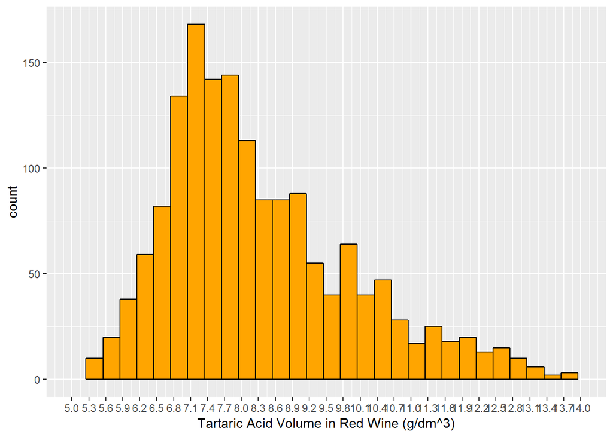

We can see the distribution is more close to right-skewed distribution.  
Most of red wines have (tartaric acid) between (6-10) g / dm^3.  
(fixed.acidity) is a continuous variable.

```
##    Min. 1st Qu.  Median    Mean 3rd Qu.    Max.
##  0.1200  0.3900  0.5200  0.5278  0.6400  1.5800
```

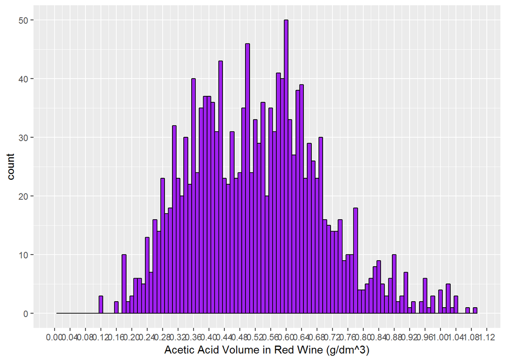

We can see that most of red wines have (acetic acid) between (0.2-0.8) g / dm^3.  
(volatile.acidity) is a continuous variable.

```
##    Min. 1st Qu.  Median    Mean 3rd Qu.    Max.
##   0.000   0.090   0.260   0.271   0.420   1.000
```

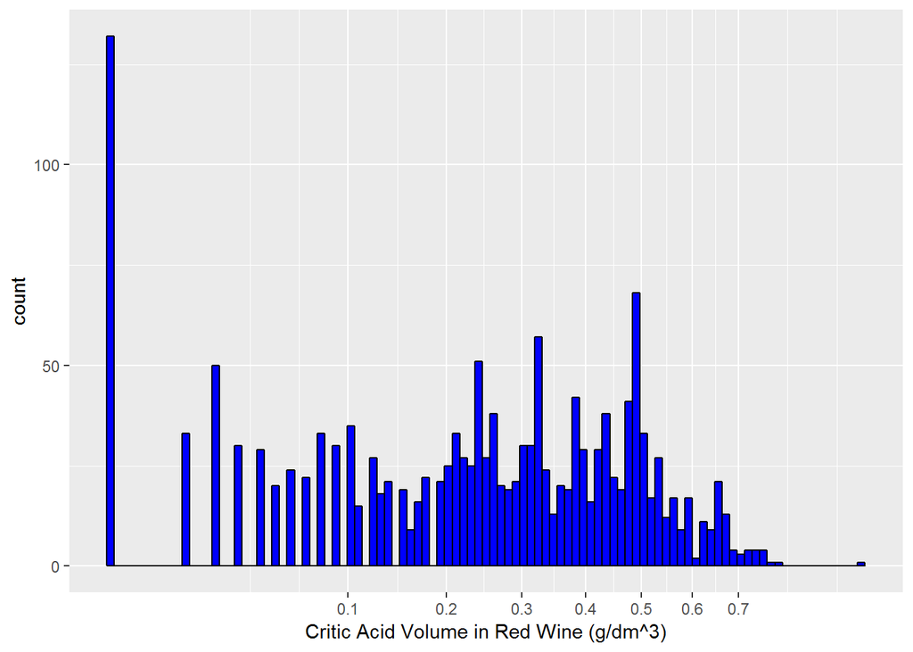

We can see that most of red wines have (citric acid) between (0.2-0.7) g / dm^3.  
(citric.acid) is a continuous variable.

```
##   X fixed.acidity volatile.acidity citric.acid residual.sugar chlorides
## 1 1           7.4             0.70        0.00            1.9     0.076
## 2 2           7.8             0.88        0.00            2.6     0.098
## 3 3           7.8             0.76        0.04            2.3     0.092
## 4 4          11.2             0.28        0.56            1.9     0.075
## 5 5           7.4             0.70        0.00            1.9     0.076
## 6 6           7.4             0.66        0.00            1.8     0.075
##   free.sulfur.dioxide total.sulfur.dioxide density   pH sulphates alcohol
## 1                  11                   34  0.9978 3.51      0.56     9.4
## 2                  25                   67  0.9968 3.20      0.68     9.8
## 3                  15                   54  0.9970 3.26      0.65     9.8
## 4                  17                   60  0.9980 3.16      0.58     9.8
## 5                  11                   34  0.9978 3.51      0.56     9.4
## 6                  13                   40  0.9978 3.51      0.56     9.4
##   quality total.acids
## 1       5        8.10
## 2       5        8.68
## 3       5        8.60
## 4       6       12.04
## 5       5        8.10
## 6       5        8.06
```

```
##   fixed.acidity volatile.acidity citric.acid total.acids residual.sugar
## 1           7.4             0.70        0.00        8.10            1.9
## 2           7.8             0.88        0.00        8.68            2.6
## 3           7.8             0.76        0.04        8.60            2.3
## 4          11.2             0.28        0.56       12.04            1.9
## 5           7.4             0.70        0.00        8.10            1.9
## 6           7.4             0.66        0.00        8.06            1.8
##   chlorides free.sulfur.dioxide total.sulfur.dioxide density   pH
## 1     0.076                  11                   34  0.9978 3.51
## 2     0.098                  25                   67  0.9968 3.20
## 3     0.092                  15                   54  0.9970 3.26
## 4     0.075                  17                   60  0.9980 3.16
## 5     0.076                  11                   34  0.9978 3.51
## 6     0.075                  13                   40  0.9978 3.51
##   sulphates alcohol quality
## 1      0.56     9.4       5
## 2      0.68     9.8       5
## 3      0.65     9.8       5
## 4      0.58     9.8       6
## 5      0.56     9.4       5
## 6      0.56     9.4       5
```

```
##    Min. 1st Qu.  Median    Mean 3rd Qu.    Max.
##   5.270   7.827   8.720   9.118  10.070  17.045
```

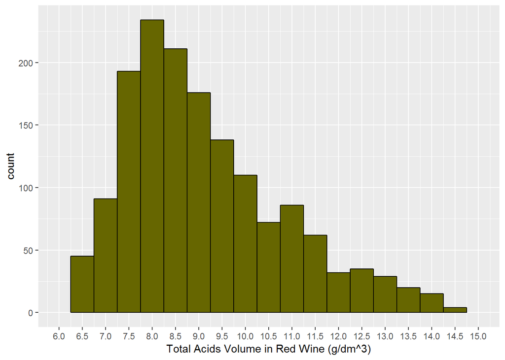

We can see that most of red wines have (total acids) between (7-10) g / dm^3.  
The distribution is more close to right-skewed distribution.  
(total.acids) is a continuous variable.

```
##    Min. 1st Qu.  Median    Mean 3rd Qu.    Max.
##   0.900   1.900   2.200   2.539   2.600  15.500
```

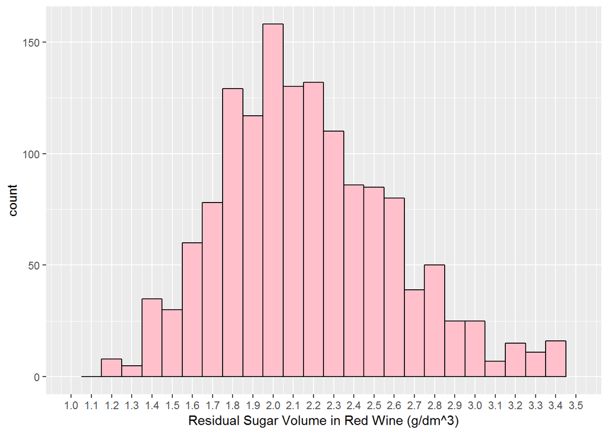

We can see that most of red wines have (residual sugar) between (1.3-3.1) g / dm^3.  
The distribution is more close to normal distribution.  
(residual.sugar) is a continuous variable.

```
##    Min. 1st Qu.  Median    Mean 3rd Qu.    Max.
## 0.01200 0.07000 0.07900 0.08747 0.09000 0.61100
```

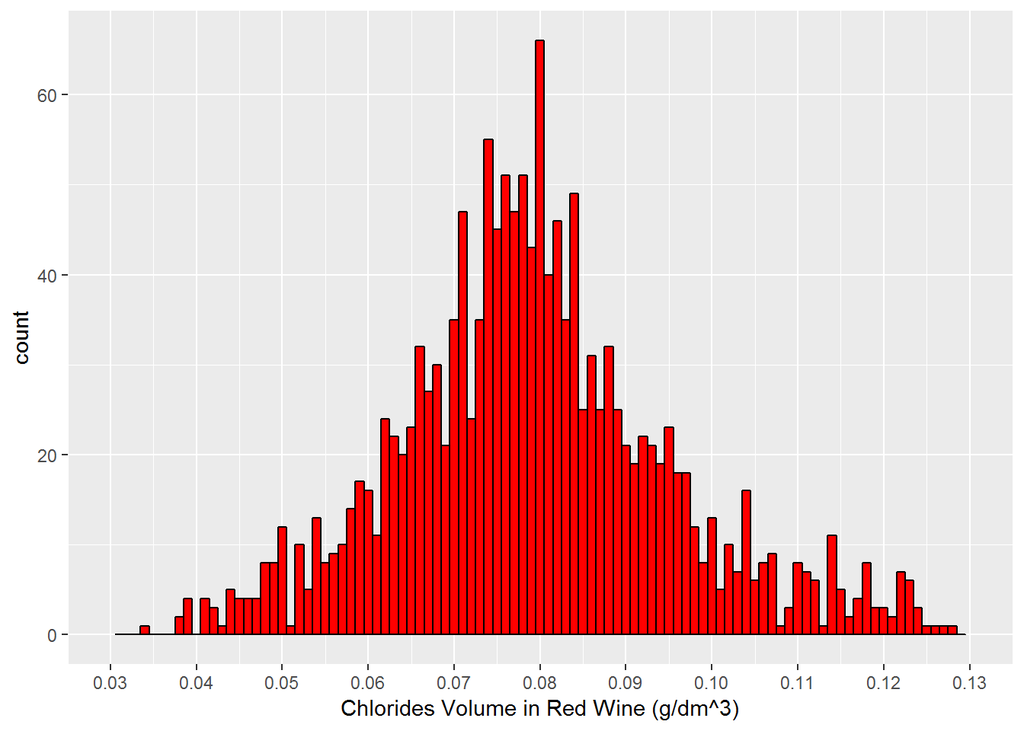

We can see that the disribution is more close to normal distribution.  
Most of red wines have chlorides between (0.05-0.11) g / dm^3.  
(chlorides) is a continuous variable.

```
##    Min. 1st Qu.  Median    Mean 3rd Qu.    Max.
##    1.00    7.00   14.00   15.87   21.00   72.00
```

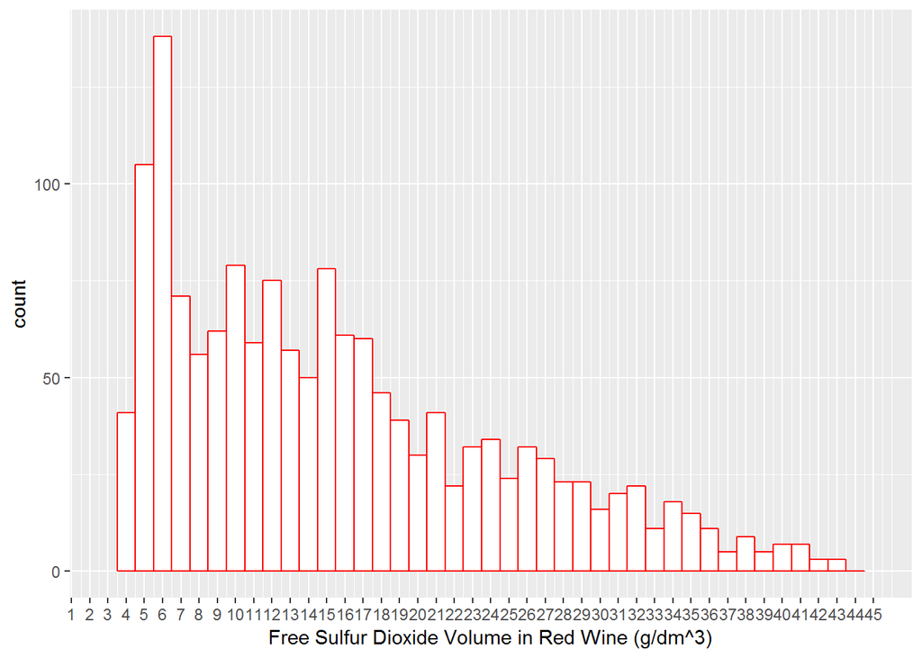

We can see that the distribution is close to right-skewed distribution.  
Most of red wines have (free sulfur dioxide) between (5-20) g / dm^3.  
(free.sulfur.dioxide) is a continuous variable.

```
##    Min. 1st Qu.  Median    Mean 3rd Qu.    Max.
##    6.00   22.00   38.00   46.47   62.00  289.00
```

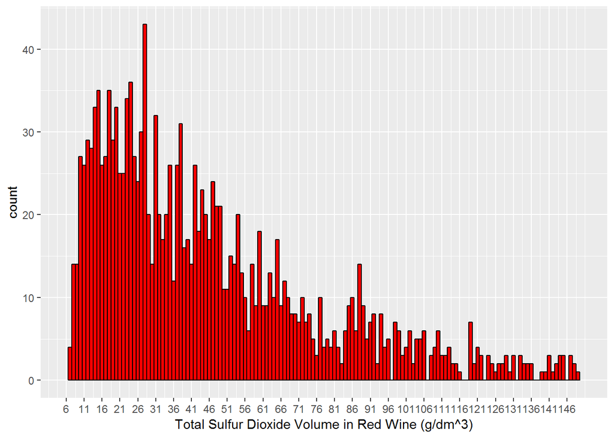

We can see that the distribution is close to right-skewed distribution.  
Most of red wines have (total sulfur dioxide) between (11-75) g / dm^3.  
(total.sulfur.dioxide) is a continuous variable.

```
##    Min. 1st Qu.  Median    Mean 3rd Qu.    Max.
##  0.9901  0.9956  0.9968  0.9967  0.9978  1.0037
```

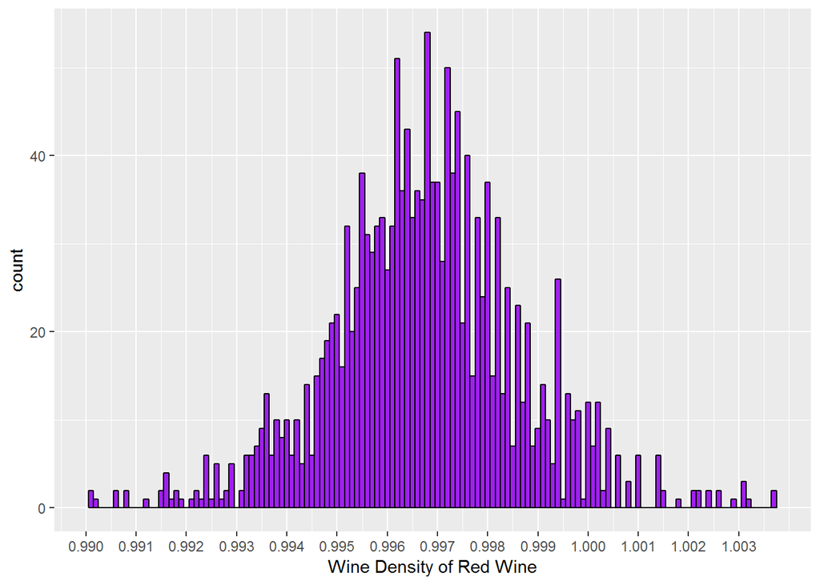

We can see that the distribution is close to normal distribution.  
Most of red wines have (density) between (0.993-1) g / dm^3.  
(density) is a continuous variable.

```
##    Min. 1st Qu.  Median    Mean 3rd Qu.    Max.
##   2.740   3.210   3.310   3.311   3.400   4.010
```

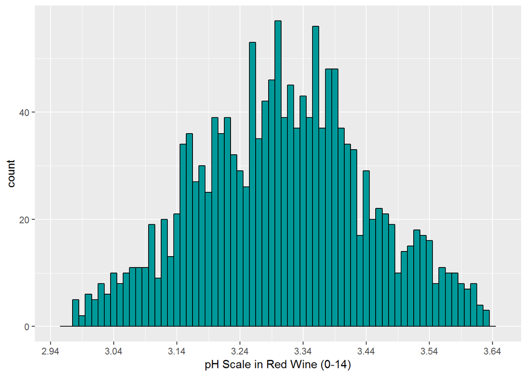

We can see that the distribution is close to normal distribution.  
Most of red wines have (pH) between (3-4).  
(pH) is a continuous variable.

```
##    Min. 1st Qu.  Median    Mean 3rd Qu.    Max.
##  0.3300  0.5500  0.6200  0.6581  0.7300  2.0000
```

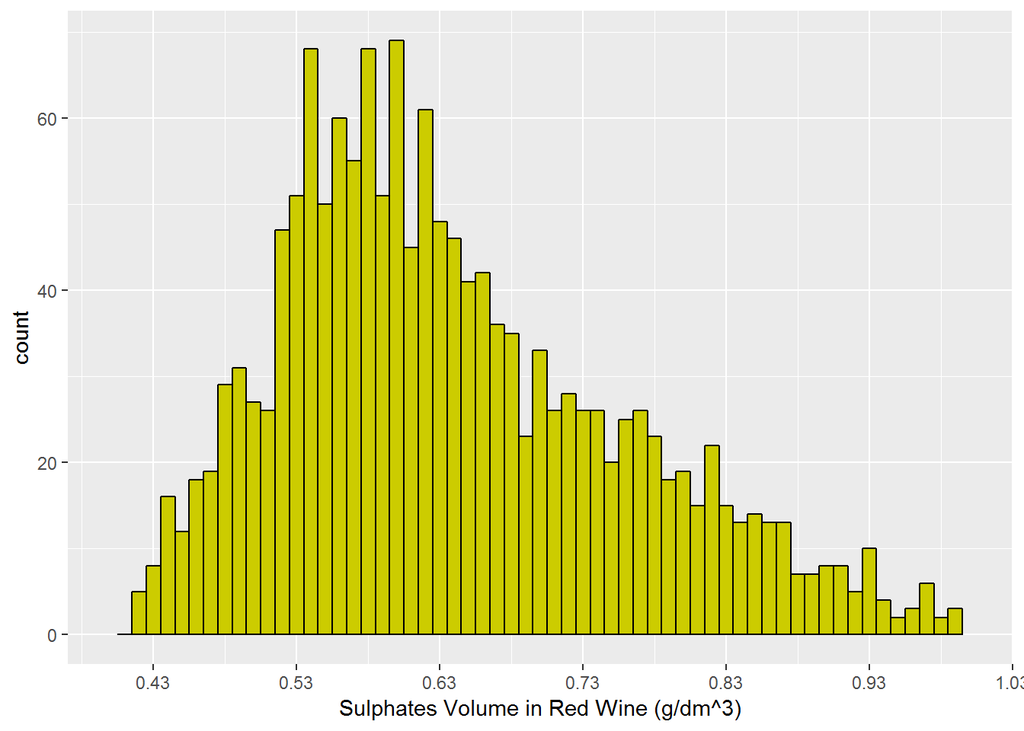

We can see that the distribution is close to right-skewed distribution.  
Most of red wines have (sulphated) between (0.43-0.9) g / dm3.  
(sulphates) is a continuous variable.

```
##    Min. 1st Qu.  Median    Mean 3rd Qu.    Max.
##    8.40    9.50   10.20   10.42   11.10   14.90
```

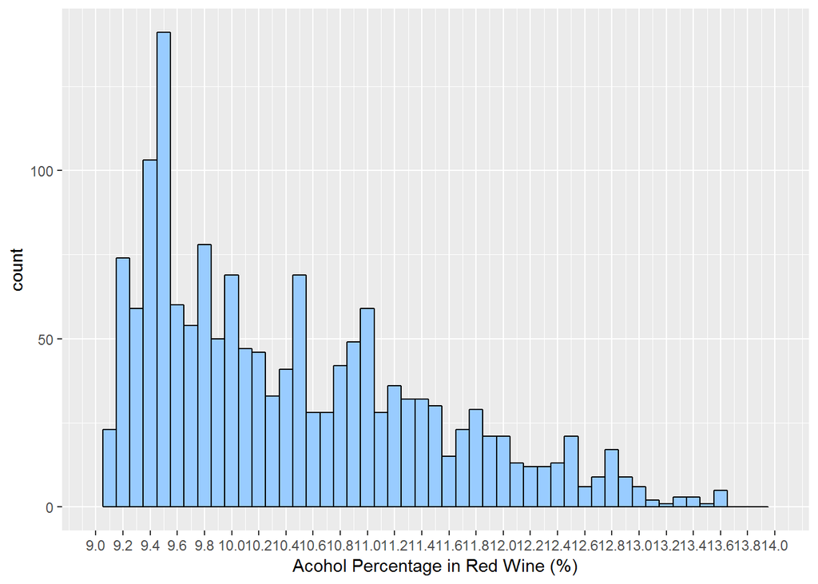

We can see that the distribution is close to right-skewed distribution.  
Most of red wines have (alcohol) between (9-12) %.  
(alchohol) is a continuous variable.

```
##    Min. 1st Qu.  Median    Mean 3rd Qu.    Max.
##   3.000   5.000   6.000   5.636   6.000   8.000
```

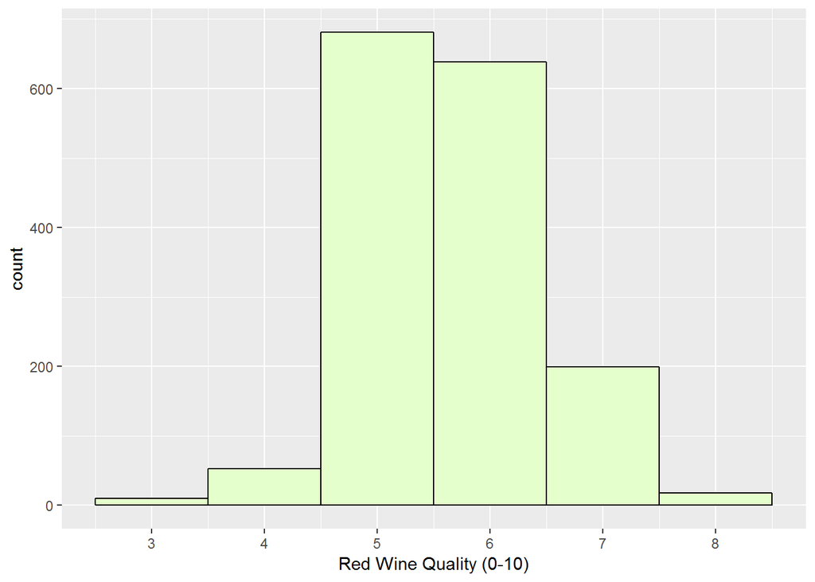

We can see that most of red wines have (quality) of 5 or 6.

# Univariate Analysis

### What is the structure of your dataset?

This dataset contains 1,599 red wines with 11 variables on the chemical properties of the red wine plus 1 variable on its quality.

### What is/are the main feature(s) of interest in your dataset?

- The volume of each acid type.
- The volume of residual sugar.
- The density of the red wine.
- The degree of (pH) which describes how much the red wine is acidic or basic.
- The alchohol percentage.
- The quality of the red wine.

### What other features in the dataset do you think will help support your investigation into your feature(s) of interest?

- How much does it take to manufacture and produce the red wine ?
- Which countries make and sell the red wine?
- What is the best time of year to make the red wine.

### Did you create any new variables from existing variables in the dataset?

Yes, I created (total.acids) variable and it equals to sum of all acid types((tartaric, (acetic, and critic) in red wine.

### Of the features you investigated, were there any unusual distributions? Did you perform any operations on the data to tidy, adjust, or change the form of the data? If so, why did you do this?

I made some adjustments when plotting each variable to make the distribution close to any familiar distribution.

# Bivariate Plots Section

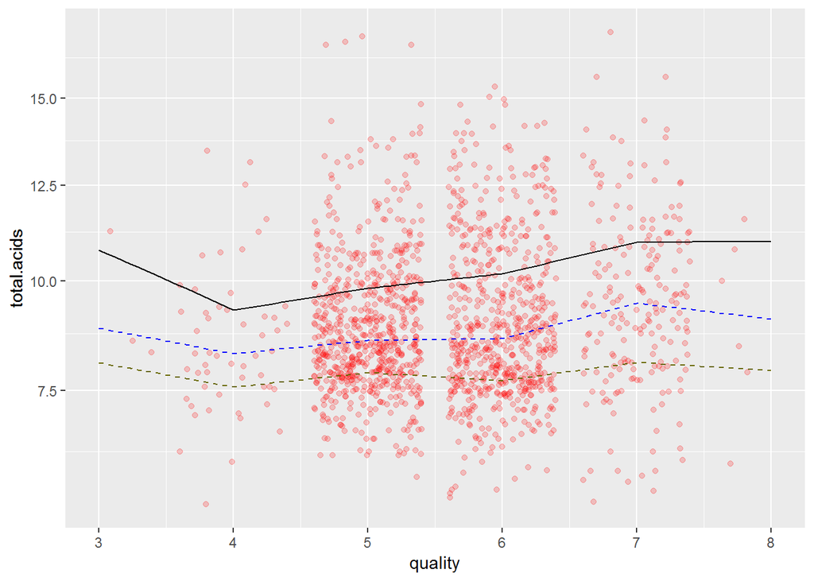

```
##
##  Pearson's product-moment correlation
##
## data:  df$total.acids and df$quality
## t = 4.1688, df = 1597, p-value = 3.227e-05
## alternative hypothesis: true correlation is not equal to 0
## 95 percent confidence interval:
##  0.05501239 0.15200177
## sample estimates:
##       cor
## 0.1037537
```

The relation between red wine quality and total acids isn’t really strong enough which means that the total acids don’t have that big effect on the red wine quality.  
75 % of red wine total acids are less than or equal 10 g / dm^3.

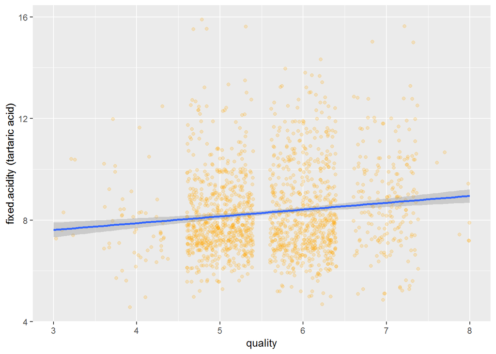

```
##
##  Pearson's product-moment correlation
##
## data:  df$quality and df$fixed.acidity
## t = 4.996, df = 1597, p-value = 6.496e-07
## alternative hypothesis: true correlation is not equal to 0
## 95 percent confidence interval:
##  0.07548957 0.17202667
## sample estimates:
##       cor
## 0.1240516
```

looks like there is a positive relation between the quality and tartaric acid volume in the red wine.  
By increasing the tartaric acid volume, the quality increases as well.

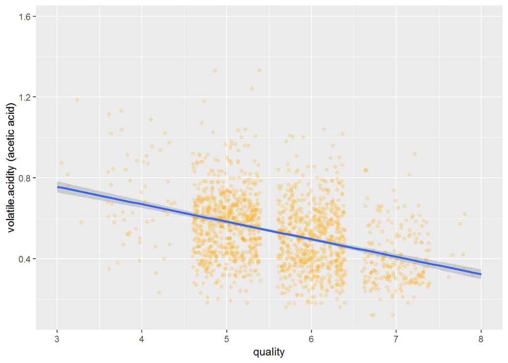

```
##
##  Pearson's product-moment correlation
##
## data:  df$quality and df$volatile.acidity
## t = -16.954, df = 1597, p-value < 2.2e-16
## alternative hypothesis: true correlation is not equal to 0
## 95 percent confidence interval:
##  -0.4313210 -0.3482032
## sample estimates:
##        cor
## -0.3905578
```

looks like there is a negative relation between the quality and acetic acid volume in the red wine. By increasing the acetic acid volume, the quality decreases.

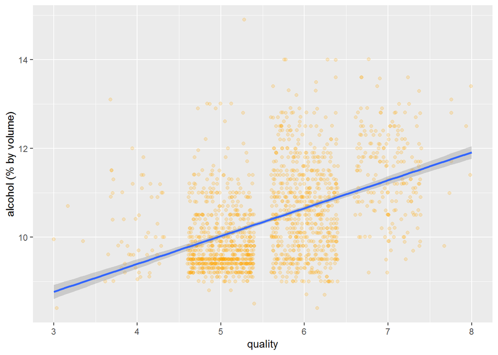

```
##
##  Pearson's product-moment correlation
##
## data:  df$quality and df$alcohol
## t = 21.639, df = 1597, p-value < 2.2e-16
## alternative hypothesis: true correlation is not equal to 0
## 95 percent confidence interval:
##  0.4373540 0.5132081
## sample estimates:
##       cor
## 0.4761663
```

looks like there is some sort of positive relation between the quality and alcohol percentage by volume. By increasing the alcohol percentage, the quality increases.

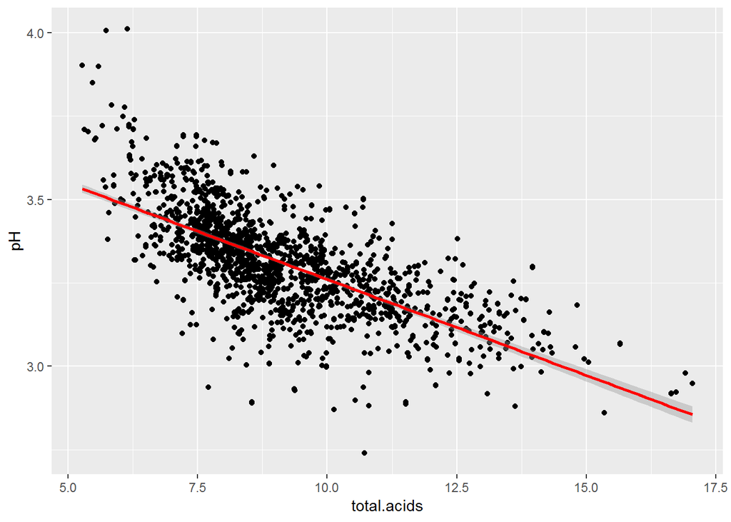

```
##
##  Pearson's product-moment correlation
##
## data:  df$total.acids and df$pH
## t = -37.418, df = 1597, p-value < 2.2e-16
## alternative hypothesis: true correlation is not equal to 0
## 95 percent confidence interval:
##  -0.7087579 -0.6564574
## sample estimates:
##        cor
## -0.6834838
```

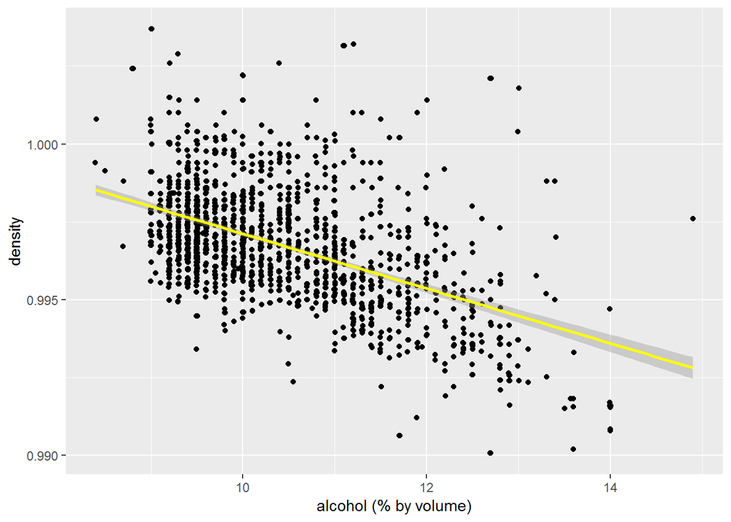

```
##
##  Pearson's product-moment correlation
##
## data:  df$alcohol and df$density
## t = -22.838, df = 1597, p-value < 2.2e-16
## alternative hypothesis: true correlation is not equal to 0
## 95 percent confidence interval:
##  -0.5322547 -0.4583061
## sample estimates:
##        cor
## -0.4961798
```

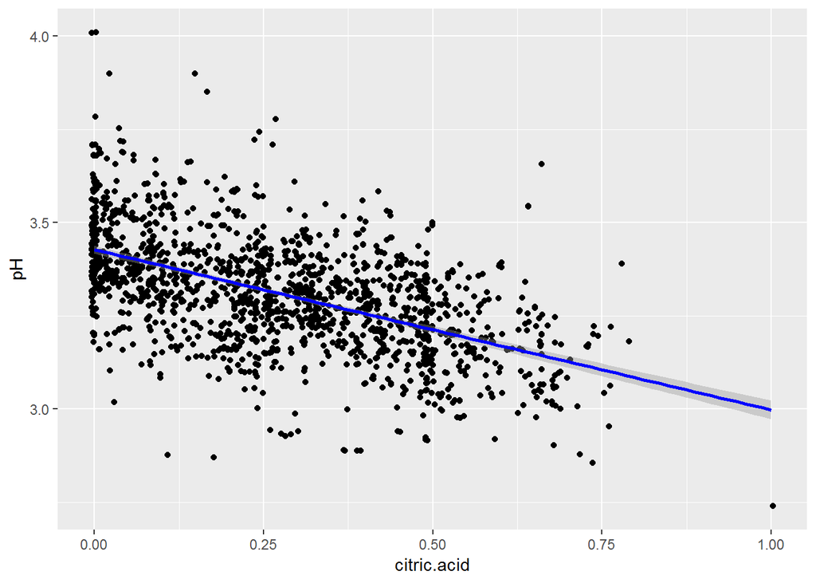

```
##
##  Pearson's product-moment correlation
##
## data:  df$citric.acid and df$pH
## t = -25.767, df = 1597, p-value < 2.2e-16
## alternative hypothesis: true correlation is not equal to 0
## 95 percent confidence interval:
##  -0.5756337 -0.5063336
## sample estimates:
##        cor
## -0.5419041
```

looks like there is a negative relation between citric acid volume in red wine and pH scale of the red wine.By increasing citric acid volume, the pH scale decreases.

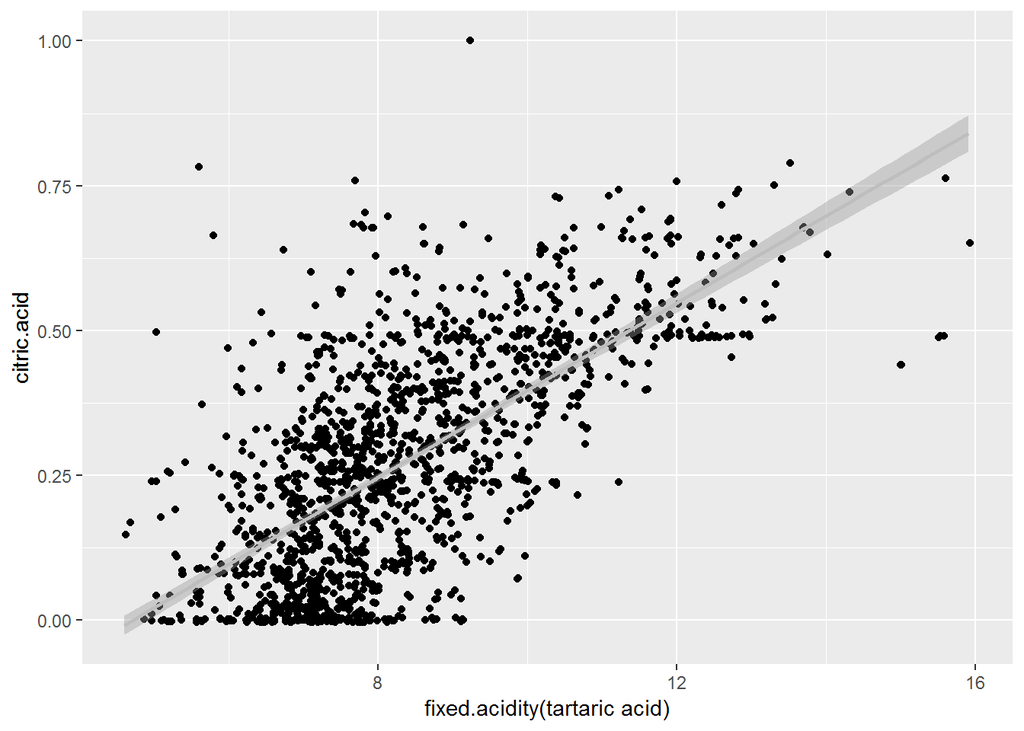

```
##
##  Pearson's product-moment correlation
##
## data:  df$fixed.acidity and df$citric.acid
## t = 36.234, df = 1597, p-value < 2.2e-16
## alternative hypothesis: true correlation is not equal to 0
## 95 percent confidence interval:
##  0.6438839 0.6977493
## sample estimates:
##       cor
## 0.6717034
```

looks like there is a positive relation between tartaric acid volume and citric acid volume in the red wine.By increasing tartaric acid volume, the citric acid volume increases as well.

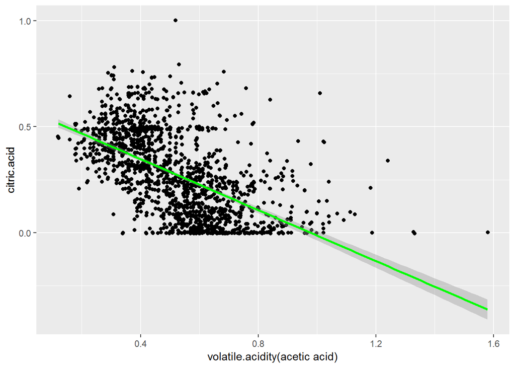

```
##
##  Pearson's product-moment correlation
##
## data:  df$volatile.acidity and df$citric.acid
## t = -26.489, df = 1597, p-value < 2.2e-16
## alternative hypothesis: true correlation is not equal to 0
## 95 percent confidence interval:
##  -0.5856550 -0.5174902
## sample estimates:
##        cor
## -0.5524957
```

looks like there is a negative relation between acetic acid volume and citric acid volume in the red wine.By increasing acetic acid volume, the citric acid volume decreases.

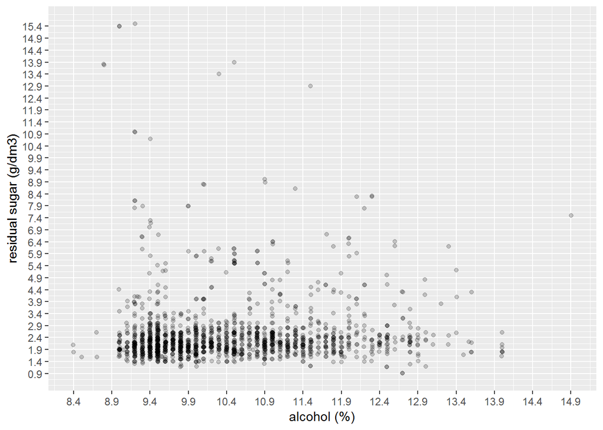

```
##
##  Pearson's product-moment correlation
##
## data:  df$alcohol and df$residual.sugar
## t = 1.6829, df = 1597, p-value = 0.09258
## alternative hypothesis: true correlation is not equal to 0
## 95 percent confidence interval:
##  -0.006960058  0.090909069
## sample estimates:
##        cor
## 0.04207544
```

Most of red wines have residual sugar between (1.5-3) g / dm3.  
From the previous plot we can observe that increasing alcohol percentage volume doesn’t really affect the residual sugar volume in red wine.

# Bivariate Analysis

### Did you observe any interesting relationships between the other features (not the main feature(s) of interest)?

- The relation between alcohol and density is negative.
- The relation between total.acids and pH is negative.

### What was the strongest relationship you found?

- The relation between citric acid and fixed.acidity (cor: 0.6717034)
- The relation between total.acids and pH (cor: -0.6834838)

# Multivariate Plots Section

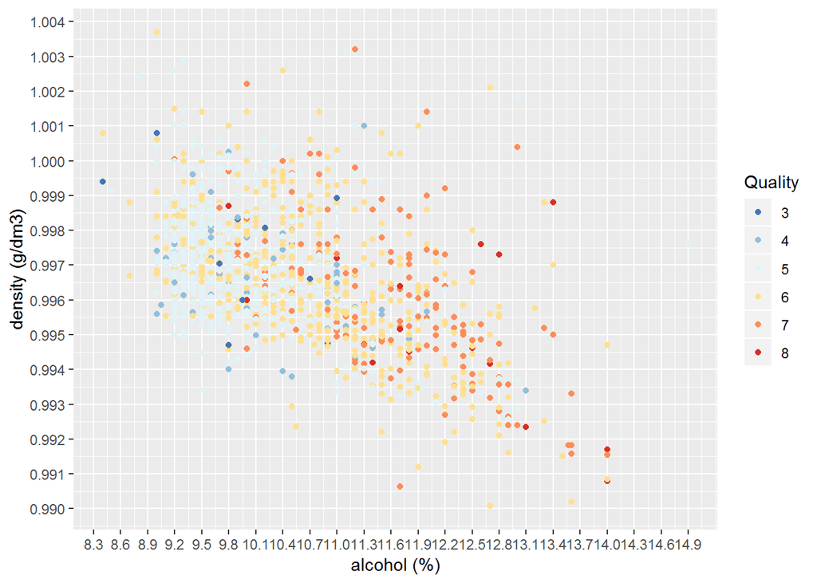

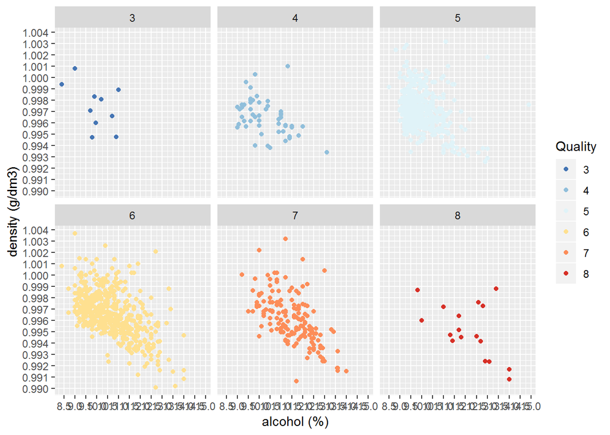

We can educe from the 2 previous scatter plots that most of high quality red wines have higher alcohol percentage and lower density.

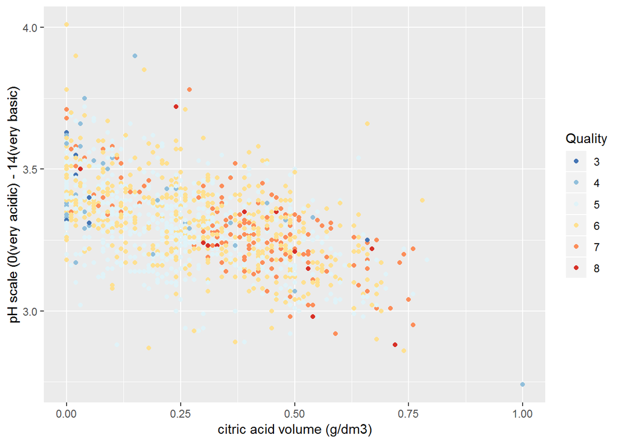

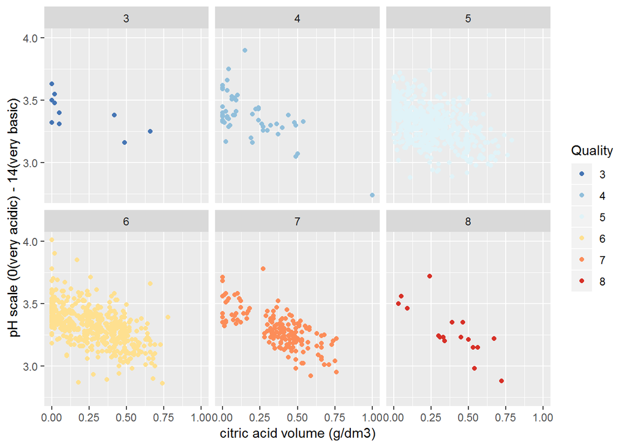

From the previous 2 scatter plots, we can observe the distribution of each red wine quality when plotting the relation between citric acid volume and pH scale.  
We can see that most of red wine qualities have citric acid volume less than 0.75 g/dm3 and ph scale between (3-4).

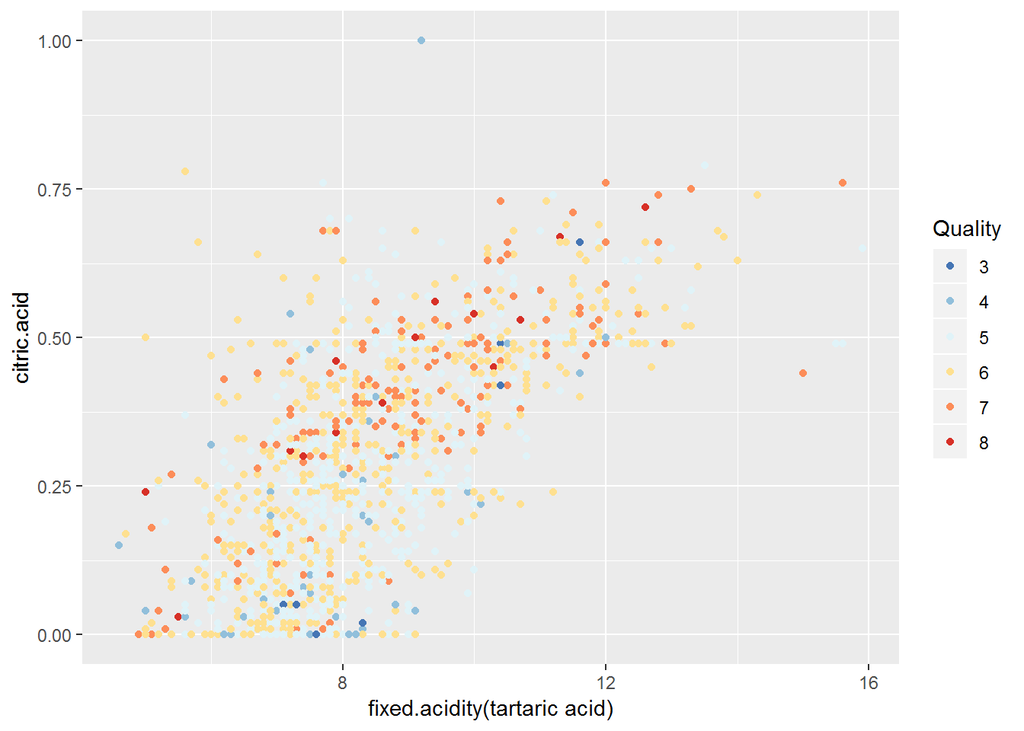

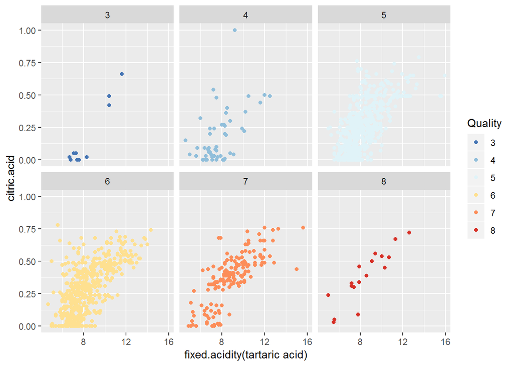

We can educe from the 2 previous scatter plots that most of high quality red wines have higher tartaric acid and citric acid.

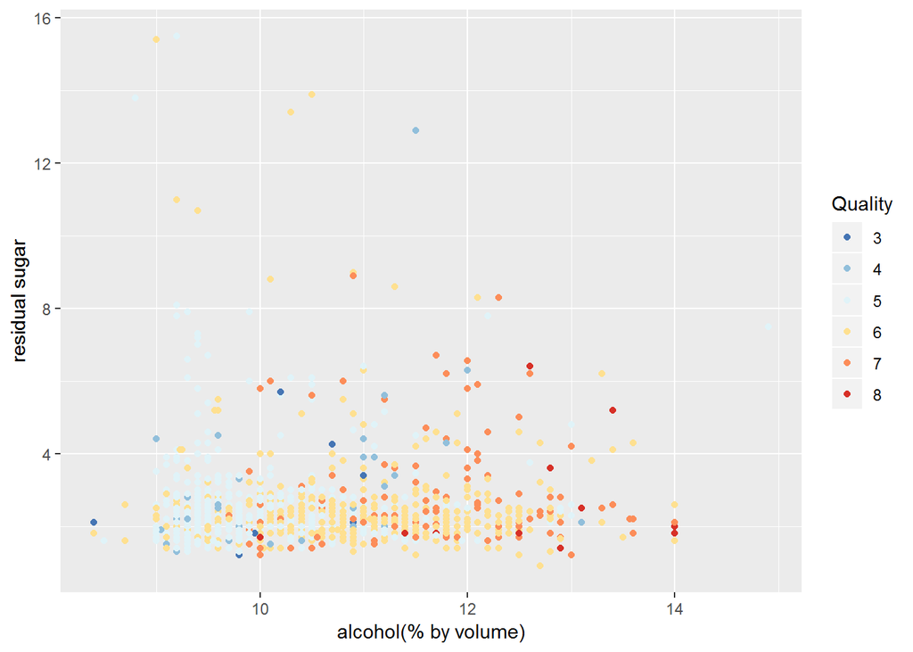

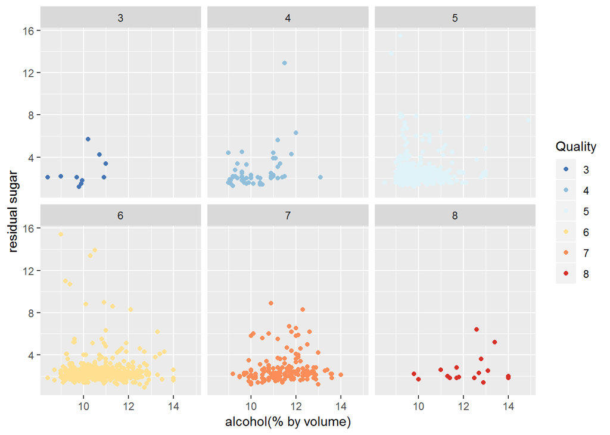

# Multivariate Analysis

### Were there any interesting or surprising interactions between features?

By plotting the relation between (alcohol) and (density) and observing each red wine quality, I found that most of high quality red wines have higher alcohol percentage and lower density, but there are also high quality red wines low have alcohol percentage and high density. We can say that also about the other Multivariate Plots, so all the previous results and plots aren’t 100% decisive, so after each plot I said (most of) not (all).

### OPTIONAL: Did you create any models with your dataset? Discuss the strengths and limitations of your model.

# Final Plots and Summary

### Plot One

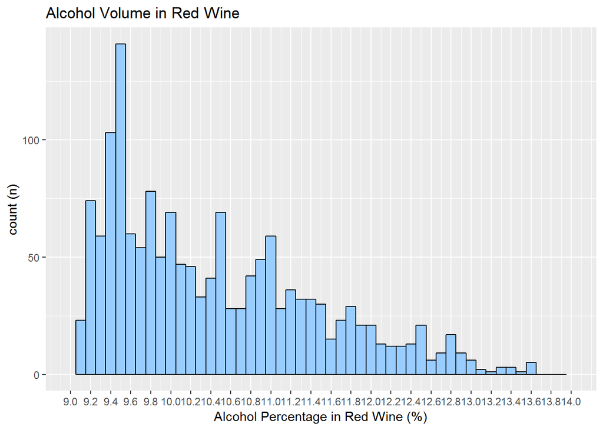

### Description One

I choosed the (alcohol percentage) variable in red wine because it’s one of things peaple talk about most and whats to know when choosing their red wine.  
We can see that the distribution is close to right-skewed distribution.  
Most of red wines have (alcohol) between (9-12) %.  
(alchohol) is a continuous variable.

### Plot Two

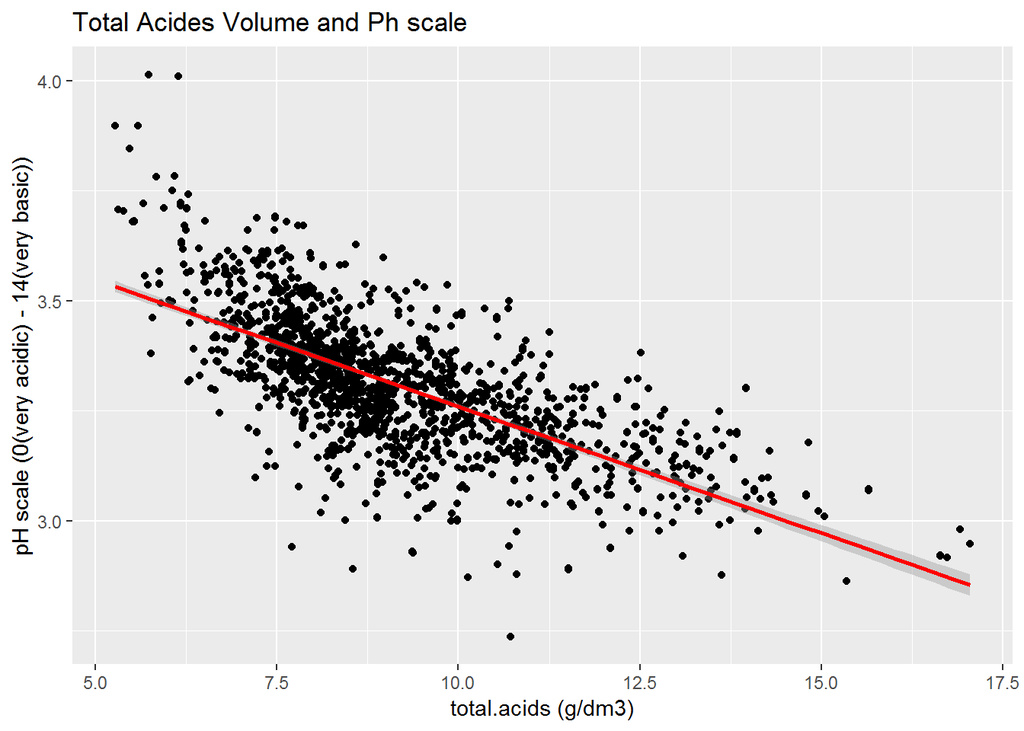

### Plot Three

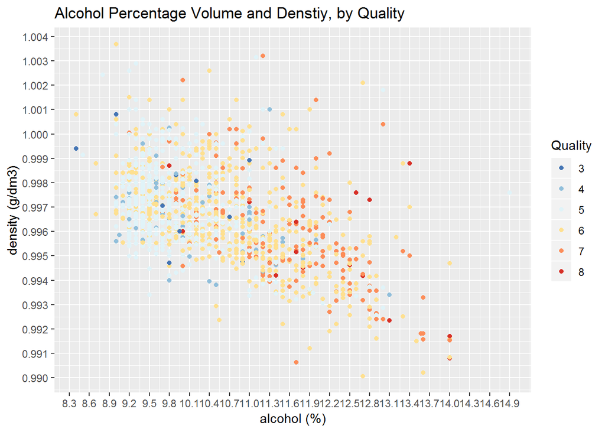

# Reflection

We explored and performed some analysis and plots on the red wine dataset. We made some observations on the features related to the red wine. We ploted one feature in a single plot, two features in the one plot, and multiple features also in one plot.The struggles were in read the dataset and understand it well before doing any analysis.I were surprised by the number of features related to the red wine, I thought it’s more simple than that. I suggest adding more features like the time needed to produce the red wine by factories and the countires that produce it in the world. Also , the price of each quality.